# Lambdas & List Comprehension

Introduction to Programming (CSSE7030)

Published

July 14, 2026

# Map and Filter

In Python, the functions `map`, `filter`, and `reduce` allow you to create and alter lists in useful ways, without having to use large, cumbersome for loops. Where appropriate, we often make use of lambda functions when calling `map`, `filter`, and `reduce`, in order to further simplify our code. For the most part, `map`, `filter`, and `reduce` are somewhat inferior to using the list comprehension syntax in Python but they do have their niche purposes. In this tutorial we will make use of both constructs to get a feel for both list comprehensions and using lambda functions.

### Task 1

The formula to convert from Fahrenheit to Celsius is given by:
$$C = 5(F-32)/9$$
Using a singular list comprehension, write a function `convert_temps` which takes a list of Fahrenheit temperatures and returns a list of converted Celsius temperatures, rounded to 1 decimal place: For example:

temps = [94, 90, 64, 75, 40, 52, 100]

convert_temps(temps)

[34.4, 32.2, 17.8, 23.9, 4.4, 11.1, 37.8]

**None**Answer**

```
temp.py
```

```python
def convert_temps(temps: list[int | float]) -> list[float]:
    """ Convert Fahrenheit temperatures to Celsius temperatures, rounded to 1 decimal place.

    Parameters:
        temps: A list of Fahrenheit temperatures.

    Returns:
        A list of temperatures equivalent to temps, but converted to Celsius.
    """

    return [round((temp - 32) * 5 / 9, 1) for temp in temps]


temps = [94, 90, 64, 75, 40, 52, 100]
print(convert_temps(temps))
```

Output

```
[34.4, 32.2, 17.8, 23.9, 4.4, 11.1, 37.8]
```

## Map

The `map` built-in takes two arguments:

1. A *function* which takes one element and returns the new transformed element.
2. An iterable (list, string, tuple etc.) which then has the function applied to each element.

and returns an iterable map object containing the result of applying the provided function to each element in the provided iterable in turn. This map object can be converted to a list using `list()`.

### Task 2

Rewrite your previous code using `map` and a lambda function, rather than a list comprehension. Apply your solution to a list of Fahrenheit temperatures to produce a list of converted Celsius temperatures.

**None**Answer**

```
temp.py
```

```python
convert_temps = lambda temp: round((temp-32) * 5 / 9, 1)
temps = [94, 90, 64, 75, 40, 52, 100]
print(list(map(convert_temps, temps)))
```

Output

```
[34.4, 32.2, 17.8, 23.9, 4.4, 11.1, 37.8]
```

### Task 3

Using a singular list comprehension, write a functions `even_15s` taking a list of integers and producing a list that only contains the numbers from the previous list that are both even and greater than 15. For example:

xs = [19, 5, 16, 8, 10, 21, 26]

even_15s(xs)

[16, 26]

**None**Answer**

```
filter.py
```

```python
def even_15s(xs: list[int]) -> list[int]:
    """ Produces a list containing only the values in xs that are both even and greater than 15.

    Parameters:
        xs: The original list to filter.

    Returns:
        A list containing only the numbers from xs that are both even and greater than 15.
    """

    return [x for x in xs if x > 15 and x % 2 == 0]

xs = [19, 5, 16, 8, 10, 21, 26]
print(even_15s(xs))
```

Output

```
[16, 26]
```

## Filter

The `filter` built-in takes two arguments:

1. A *function* which takes one element and returns True if the element should be in the filtered set, or False if it should not.
2. An iterable (list, string, tuple etc.) which then has the function applied to each element.

and returns an iterable filter object containing only the elements from the provided iterable for which the provided function returned True. This filter object can be converted to a list using `list()`.

### Task 4

Rewrite your previous code using the built-in `filter` function with a lambda function.

**None**Answer**

```
filter.py
```

```python
even_15s = lambda x: x > 15 and x % 2 == 0
xs = [19, 5, 16, 8, 10, 21, 26]
print(list(filter(even_15s, xs)))
```

Output

```
[16, 26]
```

### Task 5

Using a list comprehension, produce a list of the squares of every odd number up to 30.

**None**Answer**

```
odd_squares.py
```

```python
odd_squares = [x ** 2 for x in range(30) if x % 2 == 1]
print(odd_squares)
```

Output

```
[1, 9, 25, 49, 81, 121, 169, 225, 289, 361, 441, 529, 625, 729, 841]
```

### Task 6

Rewrite your code from the previous task using `map`, `filter`, and lambda functions.

**None**Answer**

```
odd_squares.py
```

```python
odd_squares = list(map(lambda x: x*x, filter(lambda x: x % 2 == 1, range(30))))
print(odd_squares)
```

Output

```
[1, 9, 25, 49, 81, 121, 169, 225, 289, 361, 441, 529, 625, 729, 841]
```

## Caesar Cipher

A Caesar Cipher (also known as a shift cipher) is a very simple type of cipher in which each letter in the alphabet is shifted along a set number of characters to produce the encrypted message. For example, with a ‘shift’ of 3, A becomes D, B becomes E, C becomes F, etc.

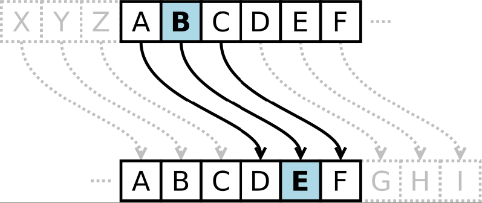

### Task 7

message = 'SECRET'

caesar_cipher(message)

'TFDSFU'

**Tip**

HINT: You can get a string of all uppercase characters by importing ascii_uppercase from the string module: `from string import ascii_uppercase` You may find the built-in functions `ord` and `chr` useful, in conjunction with an ASCII table

**None**Answer**

```
cipher.py
```

```python
def caesar_cipher(message): return ''.join(
    [chr(((ord(c) - ord('A') + 1) % 26) + ord('A'))
     for c in message])


message = 'SECRET'
print(caesar_cipher(message))
```

Output

```
TFDSFU
```

### Task 8

Modify your Caesar Cipher so that it can now handle spaces in the original message. The encrypted messages should have spaces where the original had them.

**None**Answer**

```
cipher.py
```

```python
caesar_cipher = lambda message: ''.join(
    [' ' if c == ' ' else chr(((ord(c) - ord('A') + 1) % 26) + ord('A'))
    for c in message])

message = 'SECRET TARGET'
print(caesar_cipher(message))
```

Output

```
TFDSFU UBSHFU
```